# Practical Homework-2

Sravya Murala

2026-04-25

## Introduction

This homework is worked at predicting whether a person has ever been diagnosed with cancer using their demographics and lifestyle behaviors. The data is from the 2022 National Health Interview Survey (NHIS), accessed through IPUMS Health Surveys. I tune three SVM kernels the linear, radial, and polynomial using 5-fold cross-validation, then compare them on a held-out test set. The goal is to see whether non-linear kernels capture more signal than a simple linear one, and to identify which variables matter most for cancer prediction.

```r
library(e1071)
library(caret)
library(dplyr)
library(pROC)
```

```r
library(ggplot2)
library(gridExtra)
library(magrittr)
library(kernlab)
# Parallel processing to use multiple CPU cores
library(doParallel)
cl <- makePSOCKcluster(parallel::detectCores() - 1)  # use all cores except 1
registerDoParallel(cl)
```

#### Loading and Data Inspection

```r
# Loading the Data
nhis_df <- read.csv("/Users/sravyaaas/Documents/SML-2/practical homework-2/nhis_2022.csv")

# Checking dimensions and structure
dim(nhis_df)
```

```
## [1] 35115    48
```

```r
glimpse(nhis_df)
```

```
## Rows: 35,115
## Columns: 48
## $ YEAR        <int> 2022, 2022, 2022, 2022, 2022, 2022, 2022, 2022, 2022, 2022…
## $ SERIAL      <int> 1, 2, 2, 3, 4, 4, 5, 6, 7, 8, 9, 10, 11, 12, 13, 13, 14, 1…
## $ STRATA      <int> 143, 106, 106, 134, 106, 106, 127, 111, 143, 105, 106, 113…
## $ PSU         <int> 16, 53, 53, 13, 53, 53, 26, 11, 14, 61, 22, 17, 11, 100, 3…
## $ NHISHID     <chr> "0002022H000001", "0002022H000003", "0002022H000003", "000…
## $ REGION      <int> 4, 3, 3, 2, 3, 3, 2, 4, 4, 1, 3, 4, 3, 1, 2, 2, 3, 3, 3, 3…
## $ PERNUM      <int> 1, 1, 2, 1, 1, 2, 1, 1, 1, 1, 1, 1, 1, 1, 1, 2, 1, 2, 1, 2…
## $ NHISPID     <chr> "0002022H00000110", "0002022H00000310", "0002022H00000320"…
## $ HHX         <chr> "H000001", "H000003", "H000003", "H000006", "H000007", "H0…
## $ SAMPWEIGHT  <dbl> 8018, 10117, 7933, 2681, 10233, 7712, 8165, 18745, 12814, …
## $ ASTATFLG    <int> 1, 1, 0, 1, 1, 0, 1, 1, 1, 1, 1, 1, 1, 1, 1, 0, 1, 0, 1, 0…
## $ CSTATFLG    <int> 0, 0, 1, 0, 0, 1, 0, 0, 0, 0, 0, 0, 0, 0, 0, 1, 0, 1, 0, 1…
## $ AGE         <int> 61, 43, 12, 68, 73, 16, 73, 21, 59, 67, 29, 82, 69, 59, 49…
```

[output cut: 35 more lines]

```r
table(nhis_df$CANCEREV, useNA = "ifany")
```

```
##
##     0     1     2     7     9
##  7464 24184  3430    28     9
```

```r
# selecting Variables, confirming variables planned to use as predictors
my_vars <- c("AGE", "SEX", "POVERTY", "BMICALC",
             "MOD10DMIN", "HRSLEEP", "ALCDAYSYR", "FRUTNO")

all(my_vars %in% names(nhis_df))
```

```
## [1] TRUE
```

```r
summary(nhis_df[, my_vars])
```

```
##       AGE             SEX           POVERTY         BMICALC
##  Min.   :  0.0   Min.   :1.000   Min.   :11.00   Min.   : 11.5
##  1st Qu.: 23.0   1st Qu.:1.000   1st Qu.:24.00   1st Qu.: 24.0
##  Median : 45.0   Median :2.000   Median :33.00   Median : 28.3
##  Mean   : 45.3   Mean   :1.532   Mean   :30.28   Mean   :215.8
##  3rd Qu.: 65.0   3rd Qu.:2.000   3rd Qu.:37.00   3rd Qu.: 36.8
##  Max.   :999.0   Max.   :9.000   Max.   :37.00   Max.   :996.0
##    MOD10DMIN        HRSLEEP         ALCDAYSYR       FRUTNO
##  Min.   :  0.0   Min.   : 0.000   Min.   :  0   Min.   :  0.0
##  1st Qu.:  0.0   1st Qu.: 5.000   1st Qu.:  6   1st Qu.:  1.0
##  Median : 20.0   Median : 7.000   Median :104   Median :  3.0
##  Mean   : 34.6   Mean   : 8.135   Mean   :372   Mean   :245.5
##  3rd Qu.: 45.0   3rd Qu.: 8.000   3rd Qu.:996   3rd Qu.: 30.0
##  Max.   :999.0   Max.   :99.000   Max.   :999   Max.   :999.0
```

#### Data Cleaning

The NHIS uses sentinel codes 996, 997, 998, 999, etc. for missing,refused, or “Not in Universe” responses. These must be converted to NA before modeling, otherwise the SVM will treat “999” as a real value.

```r
# Filtering adults
nhis_clean <- subset(nhis_df, is.element(CANCEREV, c(1, 2)) & AGE >= 18 & AGE <= 85)
dim(nhis_clean)
```

```
## [1] 27552    48
```

```r
# Recoding target
nhis_clean$CANCEREV <- factor(ifelse(nhis_clean$CANCEREV == 2, "Yes", "No"),
                              levels = c("No", "Yes"))
table(nhis_clean$CANCEREV)
```

```
##
##    No   Yes
## 24129  3423
```

```r
prop.table(table(nhis_clean$CANCEREV))
```

```
##
##        No       Yes
## 0.8757622 0.1242378
```

```r
# Recoding and dropping missing values
# Keeping only columns needed for modeling
cols <- c("CANCEREV", "AGE", "SEX", "POVERTY", "BMICALC",
               "MOD10DMIN", "HRSLEEP", "ALCDAYSYR", "FRUTNO")
nhis_clean <- nhis_clean[, cols]
```

```r
# Converting to a factor as SVM treats numeric 1/2 as ordered which is wrong
nhis_clean$SEX[is.element(nhis_clean$SEX, c(7, 8, 9))] <- NA
nhis_clean$SEX <- factor(ifelse(nhis_clean$SEX == 1, "Male", "Female"),
                         levels = c("Male", "Female"))
```

```r
# 98 = Undefinable, 99 = Unknown -> NA
nhis_clean$POVERTY[is.element(nhis_clean$POVERTY, c(98, 99))] <- NA
nhis_clean$BMICALC[nhis_clean$BMICALC == 0 | nhis_clean$BMICALC >= 99] <- NA
nhis_clean$MOD10DMIN[nhis_clean$MOD10DMIN >= 996] <- NA

nhis_clean$HRSLEEP[nhis_clean$HRSLEEP == 25] <- 0.5
nhis_clean$HRSLEEP[is.element(nhis_clean$HRSLEEP, c(0, 97, 98, 99))] <- NA

nhis_clean$ALCDAYSYR[nhis_clean$ALCDAYSYR >= 995] <- NA

nhis_clean$FRUTNO[nhis_clean$FRUTNO >= 995] <- NA
```

```r
# Dropping rows with NAs in any predictor
nhis_clean <- na.omit(nhis_clean)

# Verify the cleaned data
dim(nhis_clean)
```

```
## [1] 21261     9
```

```r
summary(nhis_clean)
```

```
##  CANCEREV         AGE            SEX           POVERTY         BMICALC
##  No :18505   Min.   :18.00   Male  :10122   Min.   :11.00   Min.   :15.20
##  Yes: 2756   1st Qu.:38.00   Female:11139   1st Qu.:31.00   1st Qu.:24.00
##              Median :55.00                  Median :34.00   Median :27.30
##              Mean   :53.24                  Mean   :31.11   Mean   :28.03
##              3rd Qu.:68.00                  3rd Qu.:37.00   3rd Qu.:31.30
##              Max.   :85.00                  Max.   :37.00   Max.   :52.70
##    MOD10DMIN         HRSLEEP         ALCDAYSYR          FRUTNO
##  Min.   :  0.00   Min.   : 1.000   Min.   :  0.00   Min.   :  0.000
##  1st Qu.:  0.00   1st Qu.: 6.000   1st Qu.:  1.00   1st Qu.:  1.000
##  Median : 30.00   Median : 7.000   Median : 24.00   Median :  2.000
##  Mean   : 44.21   Mean   : 7.115   Mean   : 67.27   Mean   :  3.786
##  3rd Qu.: 60.00   3rd Qu.: 8.000   3rd Qu.:104.00   3rd Qu.:  4.000
##  Max.   :720.00   Max.   :24.000   Max.   :365.00   Max.   :120.000
```

```r
# checking for class balance
table(nhis_clean$CANCEREV)
```

```
##
##    No   Yes
## 18505  2756
```

```r
round(prop.table(table(nhis_clean$CANCEREV)) * 100, 2)
```

```
##
##    No   Yes
## 87.04 12.96
```

### Exploratory Data Analysis

Before modeling, Its important that we look at how the target relates to a few key predictors. This helps confirm that the cleaned data behaves the way we would expect and gives a sense of which variables might carry signal.

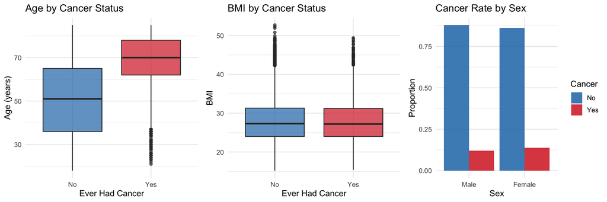

```r
# Age by cancer status
p1 <- ggplot(nhis_clean, aes(x = CANCEREV, y = AGE, fill = CANCEREV)) +
  geom_boxplot(alpha = 0.7) +
  scale_fill_manual(values = c("No" = "#1f77b4", "Yes" = "#d62728")) +
  labs(title = "Age by Cancer Status", x = "Ever Had Cancer", y = "Age (years)") +
  theme_minimal(base_size = 12) +
  theme(legend.position = "none")

# BMI by cancer status
p2 <- ggplot(nhis_clean, aes(x = CANCEREV, y = BMICALC, fill = CANCEREV)) +
  geom_boxplot(alpha = 0.7) +
  scale_fill_manual(values = c("No" = "#1f77b4", "Yes" = "#d62728")) +
  labs(title = "BMI by Cancer Status", x = "Ever Had Cancer", y = "BMI") +
  theme_minimal(base_size = 12) +
  theme(legend.position = "none")

# Cancer rate by sex
sex_summary <- aggregate(rep(1, nrow(nhis_clean)),
                         by = list(SEX = nhis_clean$SEX,
                                   CANCEREV = nhis_clean$CANCEREV),
                         FUN = sum)
names(sex_summary)[3] <- "n"
sex_summary$prop <- ave(sex_summary$n, sex_summary$SEX, FUN = function(x) x / sum(x))

p3 <- ggplot(sex_summary, aes(x = SEX, y = prop, fill = CANCEREV)) +
  geom_col(position = "dodge", alpha = 0.85) +
  scale_fill_manual(values = c("No" = "#1f77b4", "Yes" = "#d62728")) +
  labs(title = "Cancer Rate by Sex", x = "Sex", y = "Proportion", fill = "Cancer") +
  theme_minimal(base_size = 12)

gridExtra::grid.arrange(p1, p2, p3, nrow = 1)
```

#### Data preparation

```r
# Set seed for reproducibility
set.seed(2025)

# Stratified subsample
sample_strat <- caret::createDataPartition(nhis_clean$CANCEREV,
                                         p = 6000 / nrow(nhis_clean),
                                         list = FALSE)
nhis_sample <- nhis_clean[sample_strat, ]

# verifying sample size
dim(nhis_sample)
```

```
## [1] 6001    9
```

```r
round(prop.table(table(nhis_sample$CANCEREV)) * 100, 2)
```

```
##
##    No   Yes
## 87.04 12.96
```

```r
# Splitting train and test
train_lists <- caret::createDataPartition(nhis_sample$CANCEREV,
                                        p = 0.8,
                                        list = FALSE)
train_df <- nhis_sample[train_lists, ]
test_df  <- nhis_sample[-train_lists, ]

# Checking sizes and class balance
cat("Train set:\n")
```

```
## Train set:
```

```r
dim(train_df)
```

```
## [1] 4802    9
```

```r
table(train_df$CANCEREV)
```

```
##
##   No  Yes
## 4179  623
```

```r
cat("\nTest set:\n")
```

```
##
## Test set:
```

```r
dim(test_df)
```

```
## [1] 1199    9
```

```r
table(test_df$CANCEREV)
```

```
##
##   No  Yes
## 1044  155
```

As we know SVMs are distance-based, so features on different scales would be unfair the AGE 0-85 would dominate HRSLEEP 1-24. So we scale to mean=0, sd=1. We compute scaling parameters on the TRAINING set only, then apply those same parameters to the test set to avoid any data leakage.

```r
# scaling numeric columns
numeric_columns <- c("AGE", "POVERTY", "BMICALC", "MOD10DMIN",
                  "HRSLEEP", "ALCDAYSYR", "FRUTNO")

# scaling values
preprocessing <- caret::preProcess(train_df[, numeric_columns],
                             method = c("center", "scale"))

train_df[, numeric_columns] <- predict(preprocessing, train_df[, numeric_columns])
test_df[, numeric_columns]  <- predict(preprocessing, test_df[, numeric_columns])

summary(train_df[, numeric_columns])
```

```
##       AGE             POVERTY             BMICALC          MOD10DMIN
##  Min.   :-1.9649   Min.   :-2.621558   Min.   :-2.2267   Min.   :-0.7310
##  1st Qu.:-0.8623   1st Qu.:-0.004632   1st Qu.:-0.7244   1st Qu.:-0.7310
##  Median : 0.1300   Median : 0.387907   Median :-0.1521   Median :-0.2305
##  Mean   : 0.0000   Mean   : 0.000000   Mean   : 0.0000   Mean   : 0.0000
##  3rd Qu.: 0.7916   3rd Qu.: 0.780445   3rd Qu.: 0.6170   3rd Qu.: 0.2701
##  Max.   : 1.7288   Max.   : 0.780445   Max.   : 4.2475   Max.   :11.2825
##     HRSLEEP           ALCDAYSYR           FRUTNO
##  Min.   :-3.60122   Min.   :-0.6756   Min.   :-0.64114
##  1st Qu.:-0.79470   1st Qu.:-0.6654   1st Qu.:-0.46994
##  Median :-0.09307   Median :-0.4300   Median :-0.29873
##  Mean   : 0.00000   Mean   : 0.0000   Mean   : 0.00000
##  3rd Qu.: 0.60856   3rd Qu.: 0.3887   3rd Qu.: 0.04367
##  Max.   :10.43137   Max.   : 3.0598   Max.   :18.36249
```

#### Cross validation

```r
# CV control
cv_config <- caret::trainControl(method = "cv",
                                 number = 5,
                                 classProbs = TRUE,
                                 summaryFunction = caret::twoClassSummary,
                                 savePredictions = "final",
                                 sampling = NULL)
```

## Modeling

I am tunining three SVM kernels separately using 5-fold cross-validation, scoring each by ROC-AUC because of the class imbalance of ~13% cancer. Each kernel has its own hyperparameter grid which the linear has just C, radial adds sigma, and polynomial adds degree and scale. Class weights are passed to the SVM to address the imbalance without resampling.

#### Linear SVM Tuning

```r
# Linear kernal
grid_linearSVM <- expand.grid(C = 10^seq(-2, 2, length.out = 9))

# Class weights
class_weights <- c(No = 1, Yes = sum(train_df$CANCEREV == "No") / sum(train_df$CANCEREV == "Yes"))

set.seed(2025)
svm_linear <- caret::train(CANCEREV ~ .,
                           data          = train_df,
                           method        = "svmLinear",
                           trControl     = cv_config,
                           tuneGrid      = grid_linearSVM,
                           metric        = "ROC",
                           class.weights = class_weights)

cat("Best C for linear kernel:\n")
```

```
## Best C for linear kernel:
```

```r
print(svm_linear$bestTune)
```

```
##     C
## 3 0.1
```

```r
cat("\nFull CV results:\n")
```

```
##
## Full CV results:
```

```r
print(svm_linear$results)
```

```
##              C       ROC      Sens        Spec      ROCSD      SensSD
## 1   0.01000000 0.7903938 0.9966504 0.012838710 0.01231117 0.003319011
## 2   0.03162278 0.7904873 0.9968900 0.009638710 0.01209916 0.005046656
## 3   0.10000000 0.7905188 0.9971292 0.009638710 0.01231264 0.003446139
## 4   0.31622777 0.7905150 0.9971292 0.011238710 0.01231231 0.003446139
## 5   1.00000000 0.7904900 0.9966507 0.011238710 0.01229244 0.004427453
## 6   3.16227766 0.7905075 0.9971292 0.008025806 0.01231203 0.003446139
## 7  10.00000000 0.7904632 0.9976077 0.011238710 0.01224844 0.004143662
## 8  31.62277660 0.7904825 0.9964115 0.011238710 0.01228995 0.004931945
## 9 100.00000000 0.7904806 0.9971292 0.008025806 0.01227127 0.005186479
##        SpecSD
## 1 0.009124415
## 2 0.006720463
## 3 0.006720463
## 4 0.007170061
## 5 0.007170061
## 6 0.008032401
## 7 0.007170061
## 8 0.007170061
## 9 0.008032401
```

#### RBF- Radial SVM Tuning

```r
# RBF adds sigma to tuning
grid_radial <- expand.grid(C     = 10^seq(-1, 2, length.out = 5),
                           sigma = 10^seq(-3, 0, length.out = 5))

set.seed(2025)
svm_radial <- caret::train(CANCEREV ~ .,
                           data          = train_df,
                           method        = "svmRadial",
                           trControl     = cv_config,
                           tuneGrid      = grid_radial,
                           metric        = "ROC",
                           class.weights = class_weights)
cat("Best parameters for radial kernel:\n")
```

```
## Best parameters for radial kernel:
```

```r
print(svm_radial$bestTune)
```

```
##        sigma   C
## 3 0.03162278 0.1
```

```r
cat("\nFull CV results:\n")
```

```
##
## Full CV results:
```

```r
print(svm_radial$results)
```

```
##              C       sigma       ROC      Sens        Spec       ROCSD
## 1    0.1000000 0.001000000 0.7880733 0.9607495 0.131535484 0.013400076
## 6    0.5623413 0.001000000 0.7902986 0.9940183 0.022464516 0.013067060
## 11   3.1622777 0.001000000 0.7905382 0.9971292 0.014438710 0.012939931
## 16  17.7827941 0.001000000 0.7919117 0.9966504 0.008025806 0.013076550
## 21 100.0000000 0.001000000 0.7924323 0.9978466 0.006438710 0.013345555
## 2    0.1000000 0.005623413 0.7906810 0.9949746 0.022451613 0.012744389
## 7    0.5623413 0.005623413 0.7915069 0.9973681 0.008025806 0.013232429
## 12   3.1622777 0.005623413 0.7922855 0.9976071 0.006438710 0.013817224
## 17  17.7827941 0.005623413 0.7901419 0.9971286 0.012812903 0.014874962
## 22 100.0000000 0.005623413 0.7865791 0.9980856 0.006412903 0.016432301
## 3    0.1000000 0.031622777 0.7926880 0.9973673 0.008025806 0.013425928
## 8    0.5623413 0.031622777 0.7896873 0.9980850 0.009612903 0.015274242
## 13   3.1622777 0.031622777 0.7820255 0.9973678 0.008012903 0.018434121
## 18  17.7827941 0.031622777 0.7703807 0.9978463 0.008012903 0.020494616
```

[output cut: 37 more lines]

#### Polynomial SVM Tuning

```r
# Polynomial kernal
grid_poly <- expand.grid(C      = 10^seq(-1, 1, length.out = 3),
                         degree = c(2, 3),
                         scale  = c(0.01, 0.1, 1))

set.seed(2025)
svm_poly <- caret::train(CANCEREV ~ .,
                         data          = train_df,
                         method        = "svmPoly",
                         trControl     = cv_config,
                         tuneGrid      = grid_poly,
                         metric        = "ROC",
                         class.weights = class_weights)
cat("Best parameters for polynomial kernel:\n")
```

```
## Best parameters for polynomial kernel:
```

```r
print(svm_poly$bestTune)
```

```
##   degree scale C
## 7      2  0.01 1
```

```r
cat("\nFull CV results:\n")
```

```
##
## Full CV results:
```

```r
print(svm_poly$results)
```

```
##       C degree scale       ROC      Sens        Spec      ROCSD       SensSD
## 1   0.1      2  0.01 0.7907213 0.9961722 0.014438710 0.01351271 0.0043459096
## 7   1.0      2  0.01 0.7923341 0.9976074 0.009625806 0.01309558 0.0023921655
## 13 10.0      2  0.01 0.7900512 0.9942569 0.011225806 0.01353064 0.0048145905
## 2   0.1      2  0.10 0.7896798 0.9944965 0.014425806 0.01388744 0.0054551969
## 8   1.0      2  0.10 0.7867371 0.9961717 0.009612903 0.01465062 0.0046633177
## 14 10.0      2  0.10 0.7860097 0.9966501 0.006400000 0.01451547 0.0035280072
## 3   0.1      2  1.00 0.7860476 0.9954540 0.011212903 0.01441604 0.0061806170
## 9   1.0      2  1.00 0.7859483 0.9966501 0.008012903 0.01441408 0.0042626455
## 15 10.0      2  1.00 0.7860094 0.9966501 0.008000000 0.01436808 0.0035280072
## 4   0.1      3  0.01 0.7909799 0.9968897 0.012838710 0.01368984 0.0027535465
## 10  1.0      3  0.01 0.7915574 0.9973676 0.008038710 0.01429974 0.0023013309
## 16 10.0      3  0.01 0.7871389 0.9966499 0.004800000 0.01597455 0.0037255268
## 5   0.1      3  0.10 0.7795154 0.9968885 0.008012903 0.01900922 0.0032334713
## 11  1.0      3  0.10 0.7646349 0.9971283 0.004800000 0.01579404 0.0018145111
```

[output cut: 23 more lines]

#### Evaluation

```r
evaluate_svm <- function(model, test_data, model_name) {

  # Getting predicted probabilities
  predicted_prob <- predict(model, test_data, type = "prob")[, "Yes"]

  # ROC and AUC
  roc_curve <- pROC::roc(response  = test_data$CANCEREV,
                       predictor = predicted_prob,
                       levels    = c("No", "Yes"),
                       quiet     = TRUE)
  auc_value <- as.numeric(pROC::auc(roc_curve))

  # optimal probability threshold
  thresholds <- seq(0.05, 0.95, by = 0.01)
  f1_scores <- sapply(thresholds, function(t) {
    pred_class <- factor(ifelse(predicted_prob >= t, "Yes", "No"),
                         levels = c("No", "Yes"))
    confmatrix <- caret::confusionMatrix(pred_class, test_data$CANCEREV,
                                 positive = "Yes", mode = "everything")
    f1 <- confmatrix$byClass["F1"]
    ifelse(is.na(f1), 0, f1)
  })
  best_threshold <- thresholds[which.max(f1_scores)]

  # confusion matrix at best threshold
  pred_class <- factor(ifelse(predicted_prob >= best_threshold, "Yes", "No"),
                       levels = c("No", "Yes"))
  confmatrix <- caret::confusionMatrix(pred_class, test_data$CANCEREV,
                               positive = "Yes", mode = "everything")

  list(
    name       = model_name,
    threshold  = best_threshold,
    accuracy   = unname(confmatrix$overall["Accuracy"]),
    precision  = unname(confmatrix$byClass["Precision"]),
    recall     = unname(confmatrix$byClass["Recall"]),
    f1         = unname(confmatrix$byClass["F1"]),
    auc        = auc_value,
    confusion  = confmatrix$table,
    roc        = roc_curve,
    predicted_prob  = predicted_prob
  )
}
```

```r
# Evaulating three kernals

results_linear <- evaluate_svm(svm_linear, test_df, "Linear")
results_radial <- evaluate_svm(svm_radial, test_df, "Radial (RBF)")
results_poly   <- evaluate_svm(svm_poly,   test_df, "Polynomial")
```

```r
# Comparison
results_table <- data.frame(
  Model     = c(results_linear$name, results_radial$name, results_poly$name),
  Threshold = round(c(results_linear$threshold, results_radial$threshold, results_poly$threshold), 2),
  Accuracy  = round(c(results_linear$accuracy,  results_radial$accuracy,  results_poly$accuracy),  3),
  Precision = round(c(results_linear$precision, results_radial$precision, results_poly$precision), 3),
  Recall    = round(c(results_linear$recall,    results_radial$recall,    results_poly$recall),    3),
  F1        = round(c(results_linear$f1,        results_radial$f1,        results_poly$f1),        3),
  ROC_AUC   = round(c(results_linear$auc,       results_radial$auc,       results_poly$auc),       3)
)

print(results_table)
```

```
##          Model Threshold Accuracy Precision Recall    F1 ROC_AUC
## 1       Linear      0.15    0.718     0.270  0.690 0.388   0.772
## 2 Radial (RBF)      0.14    0.713     0.270  0.716 0.392   0.778
## 3   Polynomial      0.14    0.709     0.262  0.690 0.380   0.776
```

```r
results_table$Model <- c("Linear SVM", "Radial (RBF) SVM", "Polynomial SVM")
print(results_table)
```

```
##              Model Threshold Accuracy Precision Recall    F1 ROC_AUC
## 1       Linear SVM      0.15    0.718     0.270  0.690 0.388   0.772
## 2 Radial (RBF) SVM      0.14    0.713     0.270  0.716 0.392   0.778
## 3   Polynomial SVM      0.14    0.709     0.262  0.690 0.380   0.776
```

All three kernels perform similarly with AUC around 0.77-0.78, with radial slightly ahead. The recall is around 70% across kernels, which means the model catches about 7 out of 10 cancer cases, but precision is low which is ~27% because of the low base rate of cancer in the data. The confusion matrices below show this in raw counts.

```r
# Confusion matrices
cat("\n Linear SVM confusion matrix \n")
```

```
##
##  Linear SVM confusion matrix
```

```r
print(results_linear$confusion)
```

```
##           Reference
## Prediction  No Yes
##        No  754  48
##        Yes 290 107
```

```r
cat("\n Radial SVM confusion matrix \n")
```

```
##
##  Radial SVM confusion matrix
```

```r
print(results_radial$confusion)
```

```
##           Reference
## Prediction  No Yes
##        No  744  44
##        Yes 300 111
```

```r
cat("\n Polynomial SVM confusion matrix \n")
```

```
##
##  Polynomial SVM confusion matrix
```

```r
print(results_poly$confusion)
```

```
##           Reference
## Prediction  No Yes
##        No  743  48
##        Yes 301 107
```

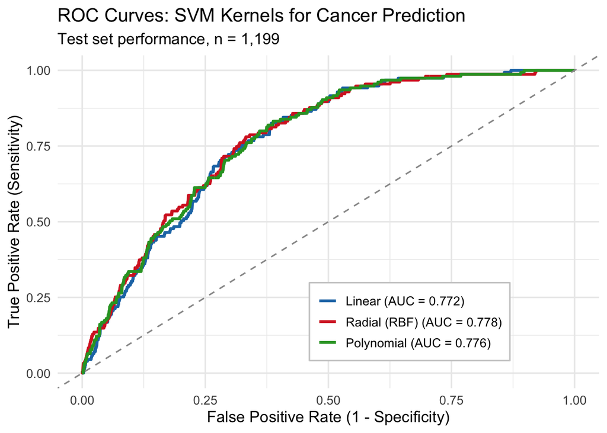

```r
# Combining ROC curves
roc_data <- rbind(
  data.frame(FPR = 1 - results_linear$roc$specificities,
             TPR = results_linear$roc$sensitivities,
             Model = "Linear"),
  data.frame(FPR = 1 - results_radial$roc$specificities,
             TPR = results_radial$roc$sensitivities,
             Model = "Radial (RBF)"),
  data.frame(FPR = 1 - results_poly$roc$specificities,
             TPR = results_poly$roc$sensitivities,
             Model = "Polynomial")
)

# AUC labels
auc_labels <- paste0(c("Linear", "Radial (RBF)", "Polynomial"),
                     " (AUC = ",
                     round(c(results_linear$auc, results_radial$auc, results_poly$auc), 3),
                     ")")
roc_data$Model <- factor(roc_data$Model,
                         levels = c("Linear", "Radial (RBF)", "Polynomial"),
                         labels = auc_labels)

roc_plot <- ggplot(roc_data, aes(x = FPR, y = TPR, color = Model)) +
  geom_line(size = 1.1) +
  geom_abline(slope = 1, intercept = 0, linetype = "dashed", color = "grey60") +
  labs(title    = "ROC Curves: SVM Kernels for Cancer Prediction",
       subtitle = "Test set performance, n = 1,199",
       x        = "False Positive Rate (1 - Specificity)",
       y        = "True Positive Rate (Sensitivity)",
       color    = NULL) +
  scale_color_manual(values = c("#1f77b4", "#d62728", "#2ca02c")) +
  theme_minimal(base_size = 13) +
  theme(legend.position = c(0.65, 0.2),
        legend.background = element_rect(fill = "white", color = "grey80"))
print(roc_plot)
```

```r
ggsave("roc_curves.png", roc_plot, width = 8, height = 6, dpi = 300)
```

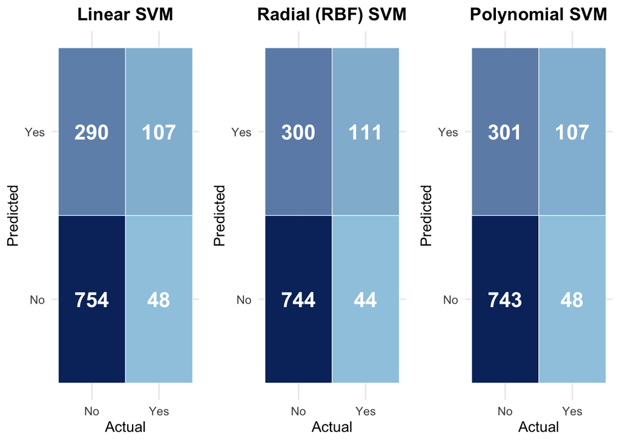

```r
# confusion matrix heatmap
make_cm_plot <- function(cm_table, title) {
  cm_df <- as.data.frame(cm_table)
  ggplot(cm_df, aes(x = Reference, y = Prediction, fill = Freq)) +
    geom_tile(color = "white") +
    geom_text(aes(label = Freq), color = "white", size = 6, fontface = "bold") +
    scale_fill_gradient(low = "#9ecae1", high = "#08306b") +
    labs(title = title, x = "Actual", y = "Predicted") +
    theme_minimal(base_size = 12) +
    theme(legend.position = "none",
          plot.title = element_text(hjust = 0.5, face = "bold"))
}

cm_plot_linear <- make_cm_plot(results_linear$confusion, "Linear SVM")
cm_plot_radial <- make_cm_plot(results_radial$confusion, "Radial (RBF) SVM")
cm_plot_poly   <- make_cm_plot(results_poly$confusion,   "Polynomial SVM")

cm_combined <- gridExtra::grid.arrange(cm_plot_linear, cm_plot_radial, cm_plot_poly,
                                       nrow = 1)
```

```r
ggsave("confusion_matrices.png", cm_combined, width = 12, height = 4, dpi = 300)
```

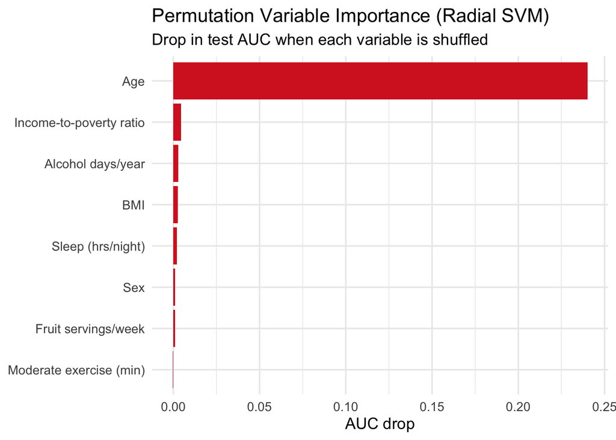

```r
# Permutation importance

permutation_importance <- function(model, data, target_col = "CANCEREV") {
  base_pred <- predict(model, data, type = "prob")[, "Yes"]
  base_auc <- as.numeric(pROC::auc(pROC::roc(data[[target_col]], base_pred,
                                             levels = c("No", "Yes"), quiet = TRUE)))

  features <- setdiff(names(data), target_col)
  importance <- numeric(length(features))
  names(importance) <- features

  for (f in features) {
    permuted <- data
    permuted[[f]] <- sample(permuted[[f]])  # shuffle this column
    new_pred <- predict(model, permuted, type = "prob")[, "Yes"]
    new_auc <- as.numeric(pROC::auc(pROC::roc(permuted[[target_col]], new_pred,
                                              levels = c("No", "Yes"), quiet = TRUE)))
    importance[f] <- base_auc - new_auc
  }
  importance
}

set.seed(2025)
imp_radial <- permutation_importance(svm_radial, test_df)

imp_df <- data.frame(Variable   = names(imp_radial),
                     Importance = as.numeric(imp_radial))
imp_df <- imp_df[order(-imp_df$Importance), ]
readable_vars <- c(
  AGE       = "Age",
  SEX       = "Sex",
  POVERTY   = "Income-to-poverty ratio",
  BMICALC   = "BMI",
  MOD10DMIN = "Moderate exercise (min)",
  HRSLEEP   = "Sleep (hrs/night)",
  ALCDAYSYR = "Alcohol days/year",
  FRUTNO    = "Fruit servings/week"
)
imp_df$Variable <- readable_vars[as.character(imp_df$Variable)]

importance_plot <- ggplot(imp_df,
                          aes(x = reorder(Variable, Importance),
                              y = Importance)) +
  geom_col(fill = "#d62728") +
  coord_flip() +
  labs(title    = "Permutation Variable Importance (Radial SVM)",
       subtitle = "Drop in test AUC when each variable is shuffled",
       x = NULL, y = "AUC drop") +
  theme_minimal(base_size = 13)

print(importance_plot)
```

```r
ggsave("variable_importance.png", importance_plot, width = 8, height = 5, dpi = 300)

print(imp_df)
```

```
##                  Variable    Importance
## 1                     Age  0.2400383142
## 3 Income-to-poverty ratio  0.0045791620
## 7       Alcohol days/year  0.0027685082
## 4                     BMI  0.0026758126
## 6       Sleep (hrs/night)  0.0020207638
## 2                     Sex  0.0010876282
## 8     Fruit servings/week  0.0009702138
## 5 Moderate exercise (min) -0.0002842665
```

```r
# Stop the parallel cluster
stopCluster(cl)
registerDoSEQ()
```

## Summary

Across all three kernels, the test AUC is around 0.78 and the differences between kernels are small. The permutation importance results show that AGE alone drives almost all of the predictive signal with every other variable contributing very little. This explains why the more flexible radial and polynomial kernels do not beat the linear kernel by much. The full discussion of these results, including limitations and implications is in the poster.